# Data Science Accelerator - Month 2 Week 2

Caio Costa

11/5/2017

# Exercise 28.2.1.1

Create one plot on the fuel economy data with customised title, subtitle, caption, x, y, and colour labels.

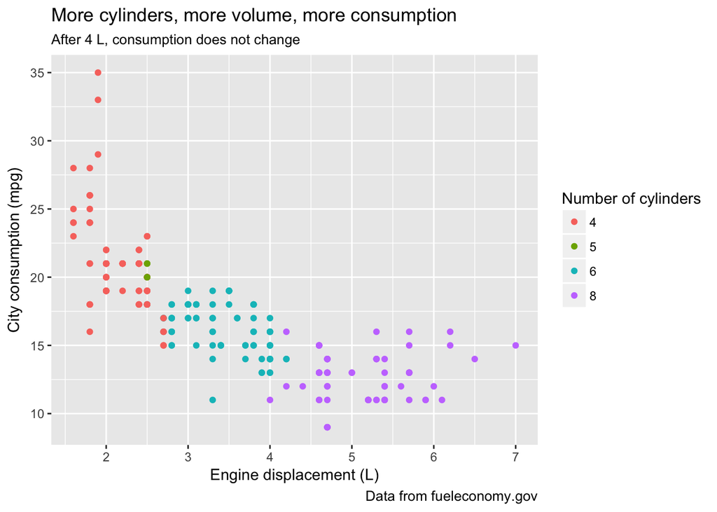

```r
ggplot(mpg, aes(displ, cty)) +
  geom_point(aes(color = as.factor(cyl))) +
  labs(title = "More cylinders, more volume, more consumption",
       subtitle = "After 4 L, consumption does not change",
       x = "Engine displacement (L)",
       y = "City consumption (mpg)",
       colour = "Number of cylinders",
       caption = "Data from fueleconomy.gov")
```

# Exercise 28.2.1.2

The geom_smooth() is somewhat misleading because the hwy for large engines is skewed upwards due to the inclusion of lightweight sports cars with big engines. Use your modelling tools to fit and display a better model.

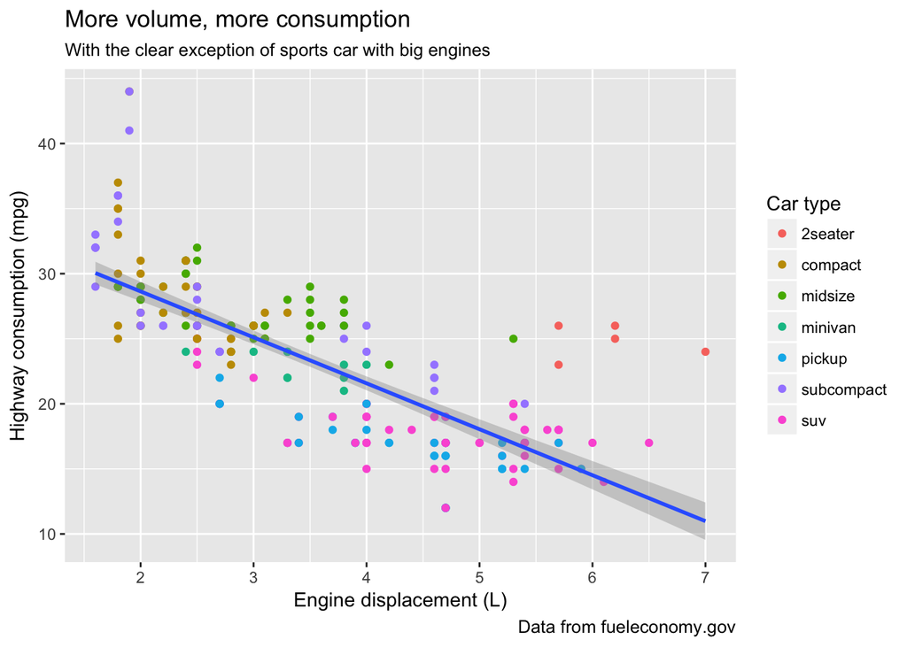

```r
ggplot(mpg, aes(displ, hwy)) +
  geom_point(aes(color = as.factor(class))) +
  geom_smooth(method = "lm") +
  labs(title = "More volume, more consumption",
       subtitle = "With the clear exception of sports car with big engines",
       x = "Engine displacement (L)",
       y = "Highway consumption (mpg)",
       colour = "Car type",
       caption = "Data from fueleconomy.gov")
```

Simplicity is king. Those sports car are not outliers enough to skew a linear model enough

# Exercise 28.2.1.3

Take an exploratory graphic that you’ve created in the last month, and add informative titles to make it easier for others to understand.

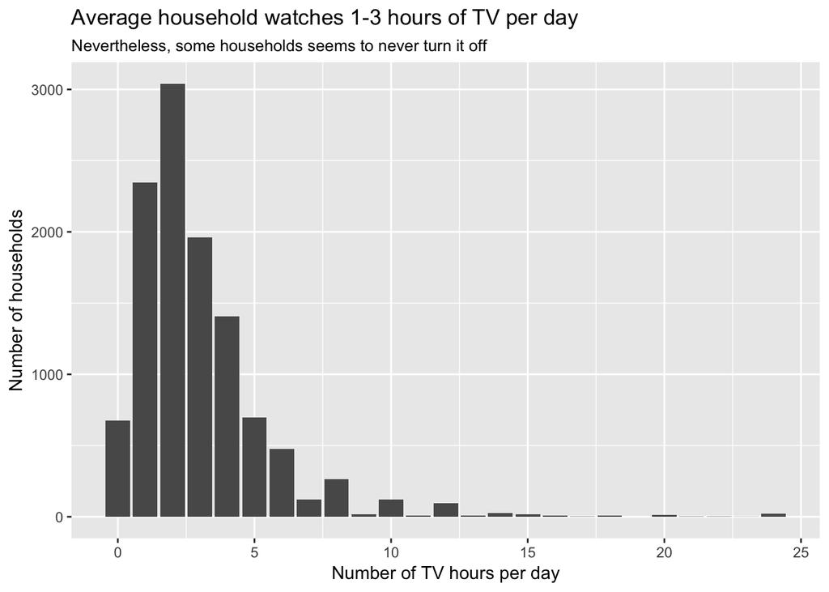

```r
#Hey Jude, don't make it bad
ggplot(gss_cat, aes(tvhours)) +
  #Take a sad chart
  geom_bar() +
  #And make it better
  labs(title = "Average household watches 1-3 hours of TV per day",
         subtitle = "Nevertheless, some households seems to never turn it off",
         x = "Number of TV hours per day",
         y = "Number of households")
```

# Exercise 28.3.1.1

Use geom_text() with infinite positions to place text at the four corners of the plot.

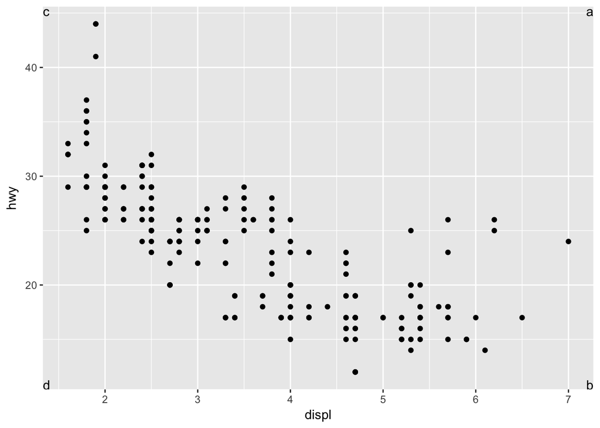

```r
label <- tibble(
  displ = c(Inf,Inf,-Inf,-Inf),
  hwy = c(Inf,-Inf,Inf,-Inf),
  label = c("a","b","c","d")
)

ggplot(mpg, aes(displ, hwy)) +
  geom_point() +
  geom_text(aes(label = label), data = label, vjust = c("top","bottom","top","bottom"), hjust = c("right","right","left","left"))
```

# Exercise 28.3.1.2

Read the documentation for annotate(). How can you use it to add a text label to a plot without having to create a tibble?

Like this:

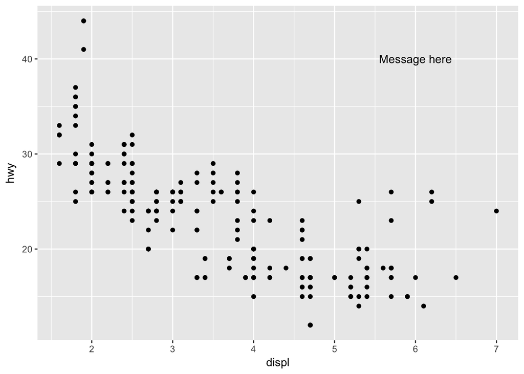

```r
ggplot(mpg, aes(displ, hwy)) +
  geom_point() +
  annotate("text", x = 6, y = 40, label = "Message here")
```

# Exercise 28.3.1.3

How do labels with geom_text() interact with faceting? How can you add a label to a single facet? How can you put a different label in each facet? (Hint: think about the underlying data.)

Fairly simple, need to put the mark the labels right.

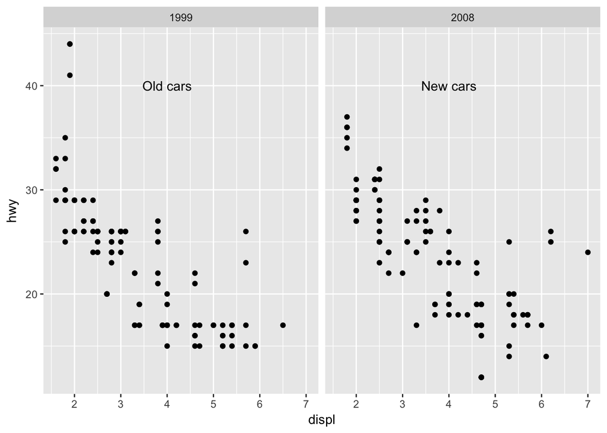

```r
label <- tibble(
  hwy = c(40,40),
  displ = c(4,4),
  year = c(1999,2008),
  label = c("Old cars", "New cars")
)
ggplot(mpg, aes(displ, hwy)) +
  geom_point() +
  facet_grid(.~ year) +
  geom_text(aes(label = label), data = label)
```

# Exercise 28.3.1.4

What arguments to geom_label() control the appearance of the background box?

The arguments label.padding, label.r and label.size controls the padding, rounded corner and border size. The fill aesthetic control the background color.

# Exercise 28.3.1.5

What are the four arguments to arrow()? How do they work? Create a series of plots that demonstrate the most important options.

- angle - controls the angle of the arrow head
- length - length of the arrow head
- ends - in which end of the line should draw arrow head, “first”, “last”, “both”
- type - “open” or “closed”, to tell if arrow head should be a closed triangle

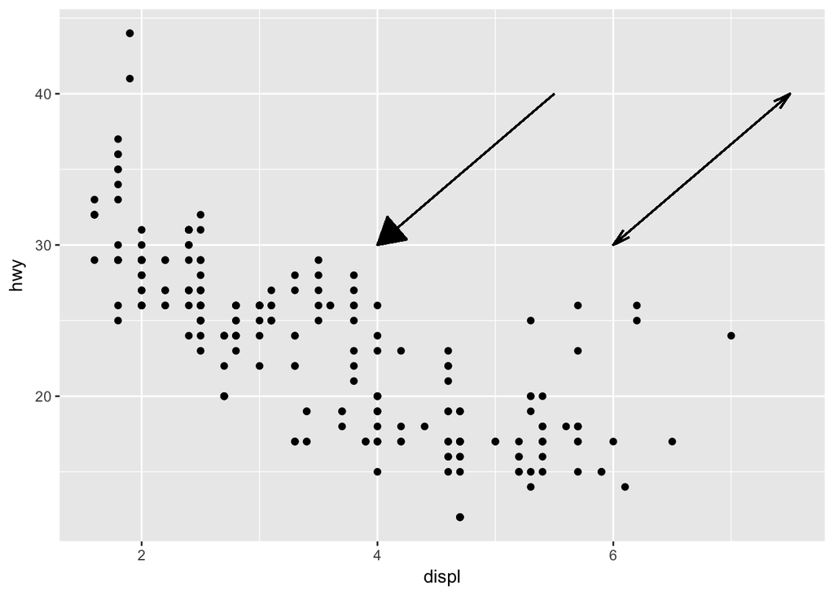

```r
ggplot(mpg, aes(displ, hwy)) +
  geom_point() +
  #Closed triangle, big head arrow
  geom_segment(aes(x = 4, y = 30, xend = 5.5, yend = 40), arrow = arrow(angle = 30, length = unit(0.25, "inches"), ends = "first", type = "closed")) +
  #Open head, small, both ends arrow
  geom_segment(aes(x = 6, y = 30, xend = 7.5, yend = 40), arrow = arrow(angle = 15, length = unit(0.15, "inches"), ends = "both", type = "open"))
```

# Exercise 28.4.4.1

Why doesn’t the following code override the default scale?

Because scale_colour_gradient override the “colour” option (which controls the border color), not the “fill” (which control the color inside)

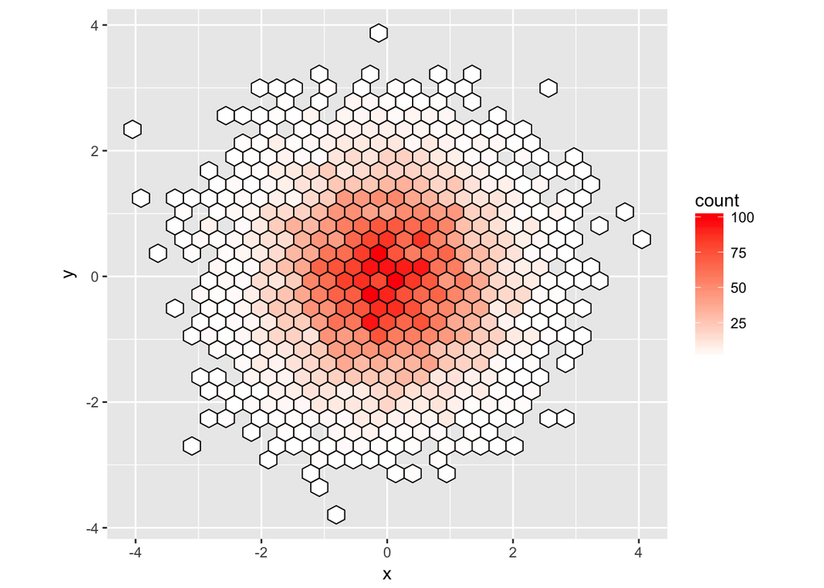

```r
ggplot(df, aes(x, y)) +
  geom_hex(colour = "black") +
  scale_fill_gradient(low = "white", high = "red") +
  coord_fixed()
```

# Exercise 28.4.4.2

What is the first argument to every scale? How does it compare to labs()?

You can pass arguments in whichever order you please. But officially, the first argument is name, which is the name of the scale and used as axis or legend title.

labs() do not have a formal first argument. You can pass an aes() or directly refer to “title”, “subtitle” or others.

# Exercise 28.4.4.3

Change the display of the presidential terms by:

- Combining the two variants shown above.
- Improving the display of the y axis.
- Labelling each term with the name of the president.
- Adding informative plot labels.
- Placing breaks every 4 years (this is trickier than it seems!).

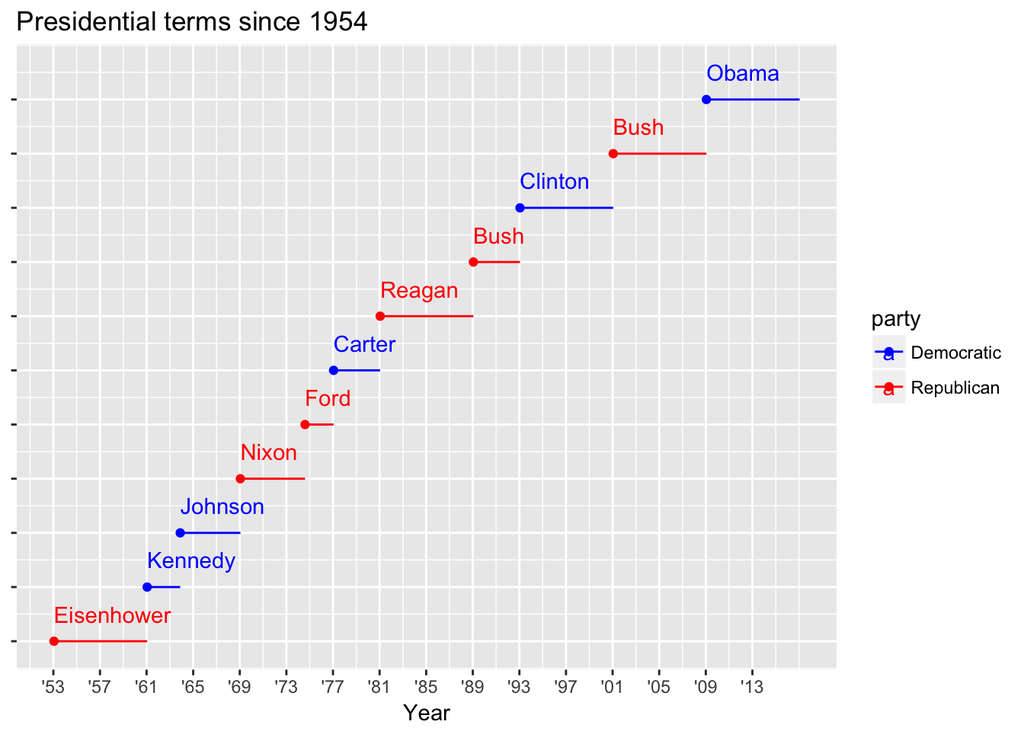

```r
presidential <- presidential %>%
  mutate(id = 33 + row_number())
#separate mutate from ggplot so we can use the id
ggplot(presidential, aes(start, id, colour = party)) +
  geom_point() +
  geom_segment(aes(xend = end, yend = id)) +
  scale_colour_manual(values = c(Republican = "red", Democratic = "blue")) +
  # breaking every 4 years and properly labeling
  scale_x_date("Year", breaks = seq(ymd('1953-01-01'),ymd('2013-01-01'),"4 years"), date_labels = "'%y") +
  # breaking on each president
  scale_y_continuous(NULL, breaks = presidential$id, labels = NULL) +
  # naming the presidents close to their terms
  geom_text(aes(label = name), hjust = 0, nudge_y = 0.5) +
  # labeling the chart
  labs(title = "Presidential terms since 1954",
       legend = "Party")
```

# Exercise 28.4.4.4

Use override.aes to make the legend on the following plot easier to see.

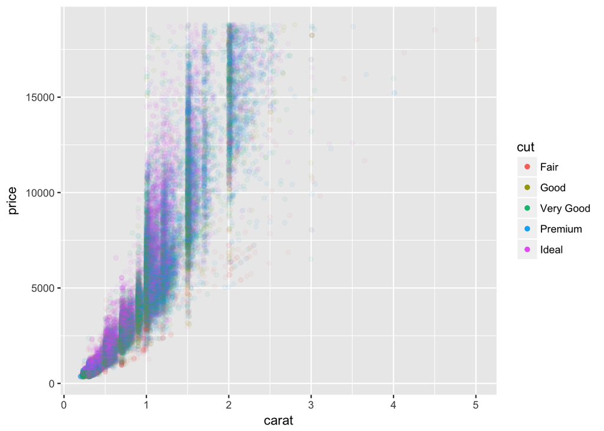

```r
ggplot(diamonds, aes(carat, price)) +
  geom_point(aes(colour = cut), alpha = 1/20) +
  guides(colour = guide_legend(override.aes = list(alpha = NA)))
```